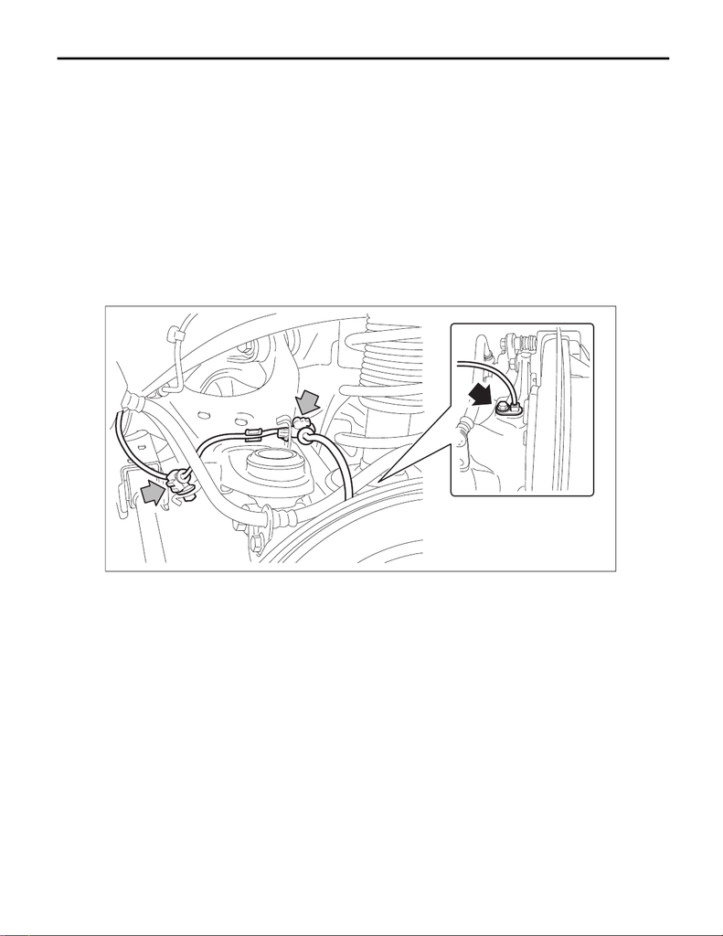

RS-9

Rear Sub Frame

REAR SUSPENSION

3. Rear Sub Frame

A: REMOVAL

1) Disconnect the ground cable from battery. <Ref. to NT-5, BATTERY, NOTE, Note.>

NOTE:

For models other than STI model, disconnect the ground terminal from battery sensor.

2) Lift up the vehicle, and then remove the rear wheels.

3) Remove the rear exhaust pipe.

• STI model: <Ref. to EX(STI)-12, REMOVAL, Rear Exhaust Pipe.>

• Except for STI model: <Ref. to EX(w/o STI)-50, REMOVAL, Rear Exhaust Pipe.>

4) Remove the propeller shaft assembly. <Ref. to DS-12, REMOVAL, Propeller Shaft.>

5) Remove the clip and bolt on the harness clamp, and remove the rear ABS wheel speed sensor.

CAUTION:

• Be careful not to damage the sensor.

• Do not apply excessive force to the sensor harness.

6) Remove the disc brake assembly - rear. <Ref. to BR-43, REMOVAL, Rear Disc Brake Assembly.>

7) Remove the cable assembly - parking brake and the parking brake shoe. <Ref. to PB-12, REMOVAL,

Parking Brake Assembly (Rear Disc Brake).>

RS-00414

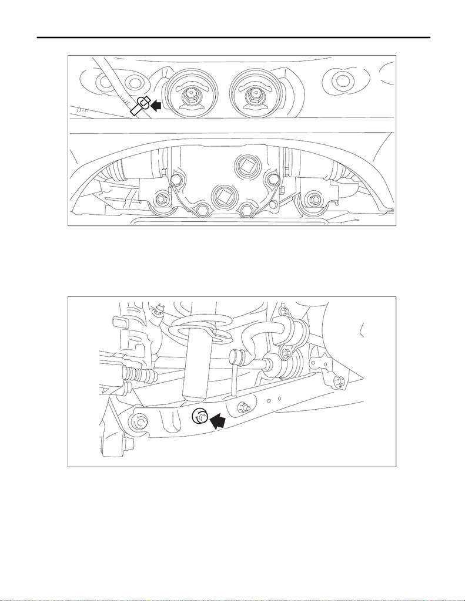

RS-10

Rear Sub Frame

REAR SUSPENSION

8) Remove the clamp of the sub rear harness.

9) Remove the sensor assembly - headlight beam leveler. (Model with auto headlight beam leveler) <Ref. to

LI-74, REMOVAL, Rear Height Sensor.>

10) Remove the fuel tank protector.

• STI model: <Ref. to FU(STI)-66, REMOVAL, Fuel Tank Protector.>

• Except for STI model: <Ref. to FU(w/o STI)-151, REMOVAL, Fuel Tank Protector.>

11) Remove the rear sub frame assembly.

(1) Remove the bolts and nuts from the lower side of rear shock absorber assembly.

RS-00484

RS-00352

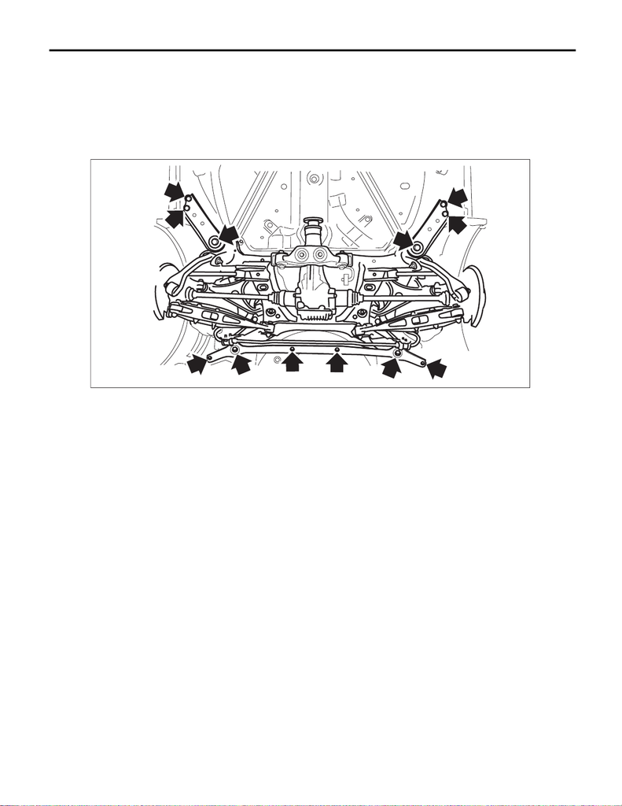

RS-11

Rear Sub Frame

REAR SUSPENSION

(2) Support the rear sub frame assembly using a transmission jack.

CAUTION:

The rear sub frame assembly is heavy. Make sure that it is horizontally-supported.

(3) Remove the bolt, and remove the left and right sub frame supports and the rear sub frame support.

(4) Remove the rear sub frame assembly.

CAUTION:

While checking there is no dragging of harness and wire, lower it slowly with a transmission jack.

12) As necessary, remove each part from the rear sub frame assembly.

RS-00533

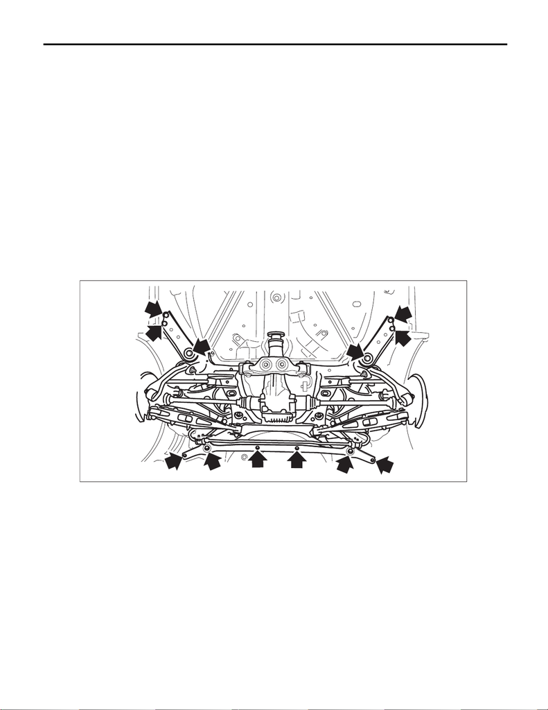

RS-12

Rear Sub Frame

REAR SUSPENSION

B: INSTALLATION

CAUTION:

• For parts which are not reusable, always use new parts.

• Always tighten the bushing in the state where the vehicle is at curb weight and the wheels are in

full contact with the ground.

• During the installation, make sure that the marking of ABS wheel speed sensor harness does not

twist.

1) Check the removed parts for wear, damage and crack, and repair or replace them if faulty.

2) Install each part to the rear sub frame assembly.

Tightening torque:

Refer to “COMPONENT” of “General Description” for the tightening torque. <Ref. to RS-3, COM-

PONENT, General Description.>

3) Install the rear sub frame assembly.

(1) Lift the rear sub frame assembly using a transmission jack.

(2) Install the right and left sub frame supports and the rear support sub frame, and install the rear sub

frame assembly.

CAUTION:

• The rear sub frame assembly is heavy. Make sure that it is horizontally-supported.

• While checking there is no dragging of harness and wire, raise it slowly with a transmission jack.

Tightening torque:

Refer to “COMPONENT” of “General Description” for the tightening torque. <Ref. to RS-3, COM-

PONENT, General Description.>

4) Install the bolts and nuts on the lower side of rear shock absorber assembly.

Tightening torque:

85 N·m (8.7 kgf-m, 62.6 ft-lb)

5) Install the fuel tank protector.

• STI model: <Ref. to FU(STI)-66, INSTALLATION, Fuel Tank Protector.>

• Except for STI model: <Ref. to FU(w/o STI)-151, INSTALLATION, Fuel Tank Protector.>

6) Install the sensor assembly - headlight beam leveler. (Model with auto headlight beam leveler)

Tightening torque:

7.5 N·m (0.8 kgf-m, 5.5 ft-lb)

RS-00533

[figure not shown]

RS-13

Rear Sub Frame

REAR SUSPENSION

7) Install the clamp of the sub rear harness.

8) Install the cable assembly - parking brake. <Ref. to PB-14, INSTALLATION, Parking Brake Assembly

(Rear Disc Brake).>

9) Install the brake hose bracket and the disc brake assembly - rear.

Tightening torque:

Brake hose bracket: 33 N·m (3.4 kgf-m, 24.3 ft-lb)

Disc brake assembly - rear (STI model): 65 N·m (6.6 kgf-m, 47.9 ft-lb)

Disc brake assembly - rear (except for STI model): 66 N·m (6.7 kgf-m, 48.7 ft-lb)

10) Install the rear ABS wheel speed sensor.

Tightening torque:

7.5 N·m (0.8 kgf-m, 5.5 ft-lb)

11) Install the propeller shaft assembly. <Ref. to DS-14, INSTALLATION, Propeller Shaft.>

12) Install the rear exhaust pipe.

• STI model: <Ref. to EX(STI)-12, INSTALLATION, Rear Exhaust Pipe.>

• Except for STI model: <Ref. to EX(w/o STI)-51, INSTALLATION, Rear Exhaust Pipe.>

13) Install the rear wheels and lower the vehicle.

Tightening torque:

120 N·m (12.2 kgf-m, 88.5 ft-lb)

14) Inspect the wheel alignment and adjust if necessary.

• Inspection: <Ref. to FS-10, INSPECTION, Wheel Alignment.>

• Adjustment: <Ref. to FS-15, ADJUSTMENT, Wheel Alignment.>

CAUTION:

When the wheel alignment has been adjusted, perform “VDC sensor midpoint setting mode” of the

VDC. <Ref. to VDC-16, ADJUSTMENT, VDC Control Module and Hydraulic Control Unit (VDCCM&H/

U).>

15) Connect the battery ground terminal. <Ref. to NT-5, BATTERY, NOTE, Note.>

NOTE:

For models other than STI model, connect the ground terminal to battery sensor.

16) Perform reinitialization of the auto headlight beam leveler system. (Model with auto headlight beam lev-

eler) <Ref. to LI-16, PROCEDURE, Auto Headlight Beam Leveler System.>

C: INSPECTION

Check the removed parts for wear, damage and crack, and repair or replace them if faulty.